# Ford GoBike System Analysis

## Introduction

The system provides users with a convenient and affordable mode of transportation in urban areas, including San Francisco and the Bay Area. Users can rent bicycles at designated stations and return them at any other station within the network. The Ford GoBike system data includes information on the number of bikes rented, trip duration, start and end stations, and other factors that can help analyze and improve the system's performance and user experience.

## Preliminary Wrangling

```python
# import all packages and set plots to be embedded inline
import numpy as np
import pandas as pd
import matplotlib.pyplot as plt
import seaborn as sns
sns.set_style('darkgrid')

%matplotlib inline
import warnings
warnings.simplefilter("ignore")
```

```python
#Load the dataset into pandas dataframe
bike_df = pd.read_csv("201902-fordgobike-tripdata.csv")
```

```python
#To get a view of what the data looks like
bike_df.head()
```

|  | duration_sec | start_time | end_time | start_station_id | start_station_name | start_station_latitude | start_station_longitude | end_station_id | end_station_name | end_station_latitude | end_station_longitude | bike_id | user_type | member_birth_year | member_gender | bike_share_for_all_trip |
| --- | --- | --- | --- | --- | --- | --- | --- | --- | --- | --- | --- | --- | --- | --- | --- | --- |
| 0 | 52185 | 2019-02-28 17:32:10.1450 | 2019-03-01 08:01:55.9750 | 21.0 | Montgomery St BART Station (Market St at 2nd St) | 37.789625 | -122.400811 | 13.0 | Commercial St at Montgomery St | 37.794231 | -122.402923 | 4902 | Customer | 1984.0 | Male | No |
| 1 | 42521 | 2019-02-28 18:53:21.7890 | 2019-03-01 06:42:03.0560 | 23.0 | The Embarcadero at Steuart St | 37.791464 | -122.391034 | 81.0 | Berry St at 4th St | 37.775880 | -122.393170 | 2535 | Customer | NaN | NaN | No |
| 2 | 61854 | 2019-02-28 12:13:13.2180 | 2019-03-01 05:24:08.1460 | 86.0 | Market St at Dolores St | 37.769305 | -122.426826 | 3.0 | Powell St BART Station (Market St at 4th St) | 37.786375 | -122.404904 | 5905 | Customer | 1972.0 | Male | No |
| 3 | 36490 | 2019-02-28 17:54:26.0100 | 2019-03-01 04:02:36.8420 | 375.0 | Grove St at Masonic Ave | 37.774836 | -122.446546 | 70.0 | Central Ave at Fell St | 37.773311 | -122.444293 | 6638 | Subscriber | 1989.0 | Other | No |
| 4 | 1585 | 2019-02-28 23:54:18.5490 | 2019-03-01 00:20:44.0740 | 7.0 | Frank H Ogawa Plaza | 37.804562 | -122.271738 | 222.0 | 10th Ave at E 15th St | 37.792714 | -122.248780 | 4898 | Subscriber | 1974.0 | Male | Yes |

```python
#To get the size of the dataset
bike_df.shape
```

```
(183412, 16)
```

```python
#Percentage of missing values
bike_df.isna().sum()/len(bike_df)*100
```

```
duration_sec               0.000000
start_time                 0.000000
end_time                   0.000000
start_station_id           0.107408
start_station_name         0.107408
start_station_latitude     0.000000
start_station_longitude    0.000000
end_station_id             0.107408
end_station_name           0.107408
end_station_latitude       0.000000
end_station_longitude      0.000000
bike_id                    0.000000
user_type                  0.000000
member_birth_year          4.506248
member_gender              4.506248
bike_share_for_all_trip    0.000000
dtype: float64
```

```python
#To check for duplicates values
bike_df.duplicated().sum()
```

```
0
```

```python
#To get an overview of the dataset
bike_df.info()
```

```
<class 'pandas.core.frame.DataFrame'>
RangeIndex: 183412 entries, 0 to 183411
Data columns (total 16 columns):
 #   Column                   Non-Null Count   Dtype
---  ------                   --------------   -----
 0   duration_sec             183412 non-null  int64
 1   start_time               183412 non-null  object
 2   end_time                 183412 non-null  object
 3   start_station_id         183215 non-null  float64
 4   start_station_name       183215 non-null  object
 5   start_station_latitude   183412 non-null  float64
 6   start_station_longitude  183412 non-null  float64
 7   end_station_id           183215 non-null  float64
 8   end_station_name         183215 non-null  object
 9   end_station_latitude     183412 non-null  float64
 10  end_station_longitude    183412 non-null  float64
 11  bike_id                  183412 non-null  int64
 12  user_type                183412 non-null  object
 13  member_birth_year        175147 non-null  float64
 14  member_gender            175147 non-null  object
 15  bike_share_for_all_trip  183412 non-null  object
dtypes: float64(7), int64(2), object(7)
memory usage: 22.4+ MB
```

```python
#To get a count of the bike user type
bike_df['user_type'].value_counts()
```

```
Subscriber    163544
Customer       19868
Name: user_type, dtype: int64
```

```python
#To get the count of the different types of gender availables
bike_df.member_gender.value_counts()
```

```
Male      130651
Female     40844
Other       3652
Name: member_gender, dtype: int64
```

```python
#Values count of bikeshare variable
bike_df['bike_share_for_all_trip'].value_counts()
```

```
No     166053
Yes     17359
Name: bike_share_for_all_trip, dtype: int64
```

## Data Cleaning

- **Missing values in some colums, drop all null values**
- **Change datatype of start_time and end_time to datatype**
- **Change the datatype of start_station_id, end_station_id, and bike_id to string datatype**
- **Change the member_gender and user_type datatype to category**
- **Extract rider age from the birth year**
- **Extract parts of the start time column to form new column(e.g year, month e.t.c)**

```python
#Create a backup of the data before cleaning
bike_df_copy = bike_df.copy()
bike_df_copy
```

|  | duration_sec | start_time | end_time | start_station_id | start_station_name | start_station_latitude | start_station_longitude | end_station_id | end_station_name | end_station_latitude | end_station_longitude | bike_id | user_type | member_birth_year | member_gender | bike_share_for_all_trip |
| --- | --- | --- | --- | --- | --- | --- | --- | --- | --- | --- | --- | --- | --- | --- | --- | --- |
| 0 | 52185 | 2019-02-28 17:32:10.1450 | 2019-03-01 08:01:55.9750 | 21.0 | Montgomery St BART Station (Market St at 2nd St) | 37.789625 | -122.400811 | 13.0 | Commercial St at Montgomery St | 37.794231 | -122.402923 | 4902 | Customer | 1984.0 | Male | No |
| 1 | 42521 | 2019-02-28 18:53:21.7890 | 2019-03-01 06:42:03.0560 | 23.0 | The Embarcadero at Steuart St | 37.791464 | -122.391034 | 81.0 | Berry St at 4th St | 37.775880 | -122.393170 | 2535 | Customer | NaN | NaN | No |
| 2 | 61854 | 2019-02-28 12:13:13.2180 | 2019-03-01 05:24:08.1460 | 86.0 | Market St at Dolores St | 37.769305 | -122.426826 | 3.0 | Powell St BART Station (Market St at 4th St) | 37.786375 | -122.404904 | 5905 | Customer | 1972.0 | Male | No |
| 3 | 36490 | 2019-02-28 17:54:26.0100 | 2019-03-01 04:02:36.8420 | 375.0 | Grove St at Masonic Ave | 37.774836 | -122.446546 | 70.0 | Central Ave at Fell St | 37.773311 | -122.444293 | 6638 | Subscriber | 1989.0 | Other | No |
| 4 | 1585 | 2019-02-28 23:54:18.5490 | 2019-03-01 00:20:44.0740 | 7.0 | Frank H Ogawa Plaza | 37.804562 | -122.271738 | 222.0 | 10th Ave at E 15th St | 37.792714 | -122.248780 | 4898 | Subscriber | 1974.0 | Male | Yes |
| ... | ... | ... | ... | ... | ... | ... | ... | ... | ... | ... | ... | ... | ... | ... | ... | ... |
| 183407 | 480 | 2019-02-01 00:04:49.7240 | 2019-02-01 00:12:50.0340 | 27.0 | Beale St at Harrison St | 37.788059 | -122.391865 | 324.0 | Union Square (Powell St at Post St) | 37.788300 | -122.408531 | 4832 | Subscriber | 1996.0 | Male | No |
| 183408 | 313 | 2019-02-01 00:05:34.7440 | 2019-02-01 00:10:48.5020 | 21.0 | Montgomery St BART Station (Market St at 2nd St) | 37.789625 | -122.400811 | 66.0 | 3rd St at Townsend St | 37.778742 | -122.392741 | 4960 | Subscriber | 1984.0 | Male | No |
| 183409 | 141 | 2019-02-01 00:06:05.5490 | 2019-02-01 00:08:27.2200 | 278.0 | The Alameda at Bush St | 37.331932 | -121.904888 | 277.0 | Morrison Ave at Julian St | 37.333658 | -121.908586 | 3824 | Subscriber | 1990.0 | Male | Yes |
| 183410 | 139 | 2019-02-01 00:05:34.3600 | 2019-02-01 00:07:54.2870 | 220.0 | San Pablo Ave at MLK Jr Way | 37.811351 | -122.273422 | 216.0 | San Pablo Ave at 27th St | 37.817827 | -122.275698 | 5095 | Subscriber | 1988.0 | Male | No |
| 183411 | 271 | 2019-02-01 00:00:20.6360 | 2019-02-01 00:04:52.0580 | 24.0 | Spear St at Folsom St | 37.789677 | -122.390428 | 37.0 | 2nd St at Folsom St | 37.785000 | -122.395936 | 1057 | Subscriber | 1989.0 | Male | No |

183412 rows × 16 columns

### Define

Drop all rows with null or missing values

### Code

```python
#Drop all rows with null values
bike_df_copy.dropna(inplace=True)
```

### Test

```python
#Test to check if null still exist
bike_df_copy.isna().sum()
```

```
duration_sec               0
start_time                 0
end_time                   0
start_station_id           0
start_station_name         0
start_station_latitude     0
start_station_longitude    0
end_station_id             0
end_station_name           0
end_station_latitude       0
end_station_longitude      0
bike_id                    0
user_type                  0
member_birth_year          0
member_gender              0
bike_share_for_all_trip    0
dtype: int64
```

### Define

Change datatype of start_time and end_time to datatype

### Code

```python
#changing datatype from object to datetime.
bike_df_copy['start_time']= pd.to_datetime(bike_df_copy['start_time'])
bike_df_copy['end_time']= pd.to_datetime(bike_df_copy['end_time'])
```

### Test

```python
print(bike_df_copy['start_time'].dtype)
print(bike_df_copy['end_time'].dtype)
```

```
datetime64[ns]
datetime64[ns]
```

### Define

Change the datatype of start_station_id, end_station_id, and bike_id to string datatype

### Code

```python
bike_df_copy['start_station_id'] = bike_df_copy['start_station_id'].astype('str')
bike_df_copy['end_station_id'] = bike_df_copy['end_station_id'].astype('str')
bike_df_copy['bike_id'] = bike_df_copy['bike_id'].astype('str')
```

### Test

```python
bike_df_copy.info()
```

```
<class 'pandas.core.frame.DataFrame'>
Int64Index: 174952 entries, 0 to 183411
Data columns (total 16 columns):
 #   Column                   Non-Null Count   Dtype
---  ------                   --------------   -----
 0   duration_sec             174952 non-null  int64
 1   start_time               174952 non-null  datetime64[ns]
 2   end_time                 174952 non-null  datetime64[ns]
 3   start_station_id         174952 non-null  object
 4   start_station_name       174952 non-null  object
 5   start_station_latitude   174952 non-null  float64
 6   start_station_longitude  174952 non-null  float64
 7   end_station_id           174952 non-null  object
 8   end_station_name         174952 non-null  object
 9   end_station_latitude     174952 non-null  float64
 10  end_station_longitude    174952 non-null  float64
 11  bike_id                  174952 non-null  object
 12  user_type                174952 non-null  object
 13  member_birth_year        174952 non-null  float64
 14  member_gender            174952 non-null  object
 15  bike_share_for_all_trip  174952 non-null  object
dtypes: datetime64[ns](2), float64(5), int64(1), object(8)
memory usage: 22.7+ MB
```

### Define

Change the member_gender and user_type datatype to category

### Code

```python
bike_df_copy['member_gender'] = bike_df_copy['member_gender'].astype('category')
bike_df_copy['user_type'] = bike_df_copy['user_type'].astype('category')
```

```python
print(bike_df_copy.member_gender.dtype)
print(bike_df_copy.user_type.dtype)
```

```
category
category
```

### Define

Extract the age of rider from birth year

### Code

```python
#Subtracting the birth_year from the current year to get age
bike_df_copy['age'] = 2023 - bike_df_copy['member_birth_year']
```

### Test

```python
bike_df_copy.info()
```

```
<class 'pandas.core.frame.DataFrame'>
Int64Index: 174952 entries, 0 to 183411
Data columns (total 17 columns):
 #   Column                   Non-Null Count   Dtype
---  ------                   --------------   -----
 0   duration_sec             174952 non-null  int64
 1   start_time               174952 non-null  datetime64[ns]
 2   end_time                 174952 non-null  datetime64[ns]
 3   start_station_id         174952 non-null  object
 4   start_station_name       174952 non-null  object
 5   start_station_latitude   174952 non-null  float64
 6   start_station_longitude  174952 non-null  float64
 7   end_station_id           174952 non-null  object
 8   end_station_name         174952 non-null  object
 9   end_station_latitude     174952 non-null  float64
 10  end_station_longitude    174952 non-null  float64
 11  bike_id                  174952 non-null  object
 12  user_type                174952 non-null  category
 13  member_birth_year        174952 non-null  float64
 14  member_gender            174952 non-null  category
 15  bike_share_for_all_trip  174952 non-null  object
 16  age                      174952 non-null  float64
dtypes: category(2), datetime64[ns](2), float64(6), int64(1), object(6)
memory usage: 21.7+ MB
```

### Define

- Change the age and year to interger dtype
- Check minimum and maximum age to filter out age that is deemed unreasonable

### Code

```python
#Change data type of age and member birth_year to int.
bike_df_copy.age = bike_df_copy.age.astype('int')
bike_df_copy.member_birth_year = bike_df_copy.member_birth_year.astype('int')
```

```python
bike_df_copy.age.describe()
```

```
count    174952.000000
mean         38.196865
std          10.118731
min          22.000000
25%          31.000000
50%          36.000000
75%          43.000000
max         145.000000
Name: age, dtype: float64
```

- Noticed the maximum age of 145 and minimum age of 22.
- 145 years is unreasonable and 22 years is acceptable.

```python
bike_df_copy = bike_df_copy[bike_df_copy['age'] <= 80]
```

### Test

```python
bike_df_copy.age.describe()
```

```
count    174719.000000
mean         38.114922
std           9.855959
min          22.000000
25%          31.000000
50%          36.000000
75%          43.000000
max          80.000000
Name: age, dtype: float64
```

```python
bike_df_copy.info()
```

```
<class 'pandas.core.frame.DataFrame'>
Int64Index: 174719 entries, 0 to 183411
Data columns (total 17 columns):
 #   Column                   Non-Null Count   Dtype
---  ------                   --------------   -----
 0   duration_sec             174719 non-null  int64
 1   start_time               174719 non-null  datetime64[ns]
 2   end_time                 174719 non-null  datetime64[ns]
 3   start_station_id         174719 non-null  object
 4   start_station_name       174719 non-null  object
 5   start_station_latitude   174719 non-null  float64
 6   start_station_longitude  174719 non-null  float64
 7   end_station_id           174719 non-null  object
 8   end_station_name         174719 non-null  object
 9   end_station_latitude     174719 non-null  float64
 10  end_station_longitude    174719 non-null  float64
 11  bike_id                  174719 non-null  object
 12  user_type                174719 non-null  category
 13  member_birth_year        174719 non-null  int32
 14  member_gender            174719 non-null  category
 15  bike_share_for_all_trip  174719 non-null  object
 16  age                      174719 non-null  int32
dtypes: category(2), datetime64[ns](2), float64(4), int32(2), int64(1), object(6)
memory usage: 20.3+ MB
```

### Define

Extract different dateparts from start_time to form new date columns

### Code

```python
#Creating a function to create new columns that extracts part of a previous date column
def process_date_column(bike_df_copy, date_column_name):
    # Define a dictionary of column names and their respective format strings
    format_strings = {
        "start_date": "%Y-%m-%d",
        "start_hour_of_day": "%H",
        "start_day_of_week": "%A",
        "start_month": "%B"
    }
    # Iterate over the dictionary items
    for column_name, format_string in format_strings.items():
         # Create a new column in the dataframe with the formatted date information
        bike_df_copy[column_name] = bike_df_copy[date_column_name].dt.strftime(format_string)
    # Return the processed dataframe
    return bike_df_copy
```

```python
#Run the above function
process_date_column(bike_df_copy, "start_time")
```

|  | duration_sec | start_time | end_time | start_station_id | start_station_name | start_station_latitude | start_station_longitude | end_station_id | end_station_name | end_station_latitude | ... | bike_id | user_type | member_birth_year | member_gender | bike_share_for_all_trip | age | start_date | start_hour_of_day | start_day_of_week | start_month |
| --- | --- | --- | --- | --- | --- | --- | --- | --- | --- | --- | --- | --- | --- | --- | --- | --- | --- | --- | --- | --- | --- |
| 0 | 52185 | 2019-02-28 17:32:10.145 | 2019-03-01 08:01:55.975 | 21.0 | Montgomery St BART Station (Market St at 2nd St) | 37.789625 | -122.400811 | 13.0 | Commercial St at Montgomery St | 37.794231 | ... | 4902 | Customer | 1984 | Male | No | 39 | 2019-02-28 | 17 | Thursday | February |
| 2 | 61854 | 2019-02-28 12:13:13.218 | 2019-03-01 05:24:08.146 | 86.0 | Market St at Dolores St | 37.769305 | -122.426826 | 3.0 | Powell St BART Station (Market St at 4th St) | 37.786375 | ... | 5905 | Customer | 1972 | Male | No | 51 | 2019-02-28 | 12 | Thursday | February |
| 3 | 36490 | 2019-02-28 17:54:26.010 | 2019-03-01 04:02:36.842 | 375.0 | Grove St at Masonic Ave | 37.774836 | -122.446546 | 70.0 | Central Ave at Fell St | 37.773311 | ... | 6638 | Subscriber | 1989 | Other | No | 34 | 2019-02-28 | 17 | Thursday | February |
| 4 | 1585 | 2019-02-28 23:54:18.549 | 2019-03-01 00:20:44.074 | 7.0 | Frank H Ogawa Plaza | 37.804562 | -122.271738 | 222.0 | 10th Ave at E 15th St | 37.792714 | ... | 4898 | Subscriber | 1974 | Male | Yes | 49 | 2019-02-28 | 23 | Thursday | February |
| 5 | 1793 | 2019-02-28 23:49:58.632 | 2019-03-01 00:19:51.760 | 93.0 | 4th St at Mission Bay Blvd S | 37.770407 | -122.391198 | 323.0 | Broadway at Kearny | 37.798014 | ... | 5200 | Subscriber | 1959 | Male | No | 64 | 2019-02-28 | 23 | Thursday | February |
| ... | ... | ... | ... | ... | ... | ... | ... | ... | ... | ... | ... | ... | ... | ... | ... | ... | ... | ... | ... | ... | ... |
| 183407 | 480 | 2019-02-01 00:04:49.724 | 2019-02-01 00:12:50.034 | 27.0 | Beale St at Harrison St | 37.788059 | -122.391865 | 324.0 | Union Square (Powell St at Post St) | 37.788300 | ... | 4832 | Subscriber | 1996 | Male | No | 27 | 2019-02-01 | 00 | Friday | February |
| 183408 | 313 | 2019-02-01 00:05:34.744 | 2019-02-01 00:10:48.502 | 21.0 | Montgomery St BART Station (Market St at 2nd St) | 37.789625 | -122.400811 | 66.0 | 3rd St at Townsend St | 37.778742 | ... | 4960 | Subscriber | 1984 | Male | No | 39 | 2019-02-01 | 00 | Friday | February |
| 183409 | 141 | 2019-02-01 00:06:05.549 | 2019-02-01 00:08:27.220 | 278.0 | The Alameda at Bush St | 37.331932 | -121.904888 | 277.0 | Morrison Ave at Julian St | 37.333658 | ... | 3824 | Subscriber | 1990 | Male | Yes | 33 | 2019-02-01 | 00 | Friday | February |
| 183410 | 139 | 2019-02-01 00:05:34.360 | 2019-02-01 00:07:54.287 | 220.0 | San Pablo Ave at MLK Jr Way | 37.811351 | -122.273422 | 216.0 | San Pablo Ave at 27th St | 37.817827 | ... | 5095 | Subscriber | 1988 | Male | No | 35 | 2019-02-01 | 00 | Friday | February |
| 183411 | 271 | 2019-02-01 00:00:20.636 | 2019-02-01 00:04:52.058 | 24.0 | Spear St at Folsom St | 37.789677 | -122.390428 | 37.0 | 2nd St at Folsom St | 37.785000 | ... | 1057 | Subscriber | 1989 | Male | No | 34 | 2019-02-01 | 00 | Friday | February |

174719 rows × 21 columns

### Test

```python
bike_df_copy
```

|  | duration_sec | start_time | end_time | start_station_id | start_station_name | start_station_latitude | start_station_longitude | end_station_id | end_station_name | end_station_latitude | ... | bike_id | user_type | member_birth_year | member_gender | bike_share_for_all_trip | age | start_date | start_hour_of_day | start_day_of_week | start_month |
| --- | --- | --- | --- | --- | --- | --- | --- | --- | --- | --- | --- | --- | --- | --- | --- | --- | --- | --- | --- | --- | --- |
| 0 | 52185 | 2019-02-28 17:32:10.145 | 2019-03-01 08:01:55.975 | 21.0 | Montgomery St BART Station (Market St at 2nd St) | 37.789625 | -122.400811 | 13.0 | Commercial St at Montgomery St | 37.794231 | ... | 4902 | Customer | 1984 | Male | No | 39 | 2019-02-28 | 17 | Thursday | February |
| 2 | 61854 | 2019-02-28 12:13:13.218 | 2019-03-01 05:24:08.146 | 86.0 | Market St at Dolores St | 37.769305 | -122.426826 | 3.0 | Powell St BART Station (Market St at 4th St) | 37.786375 | ... | 5905 | Customer | 1972 | Male | No | 51 | 2019-02-28 | 12 | Thursday | February |
| 3 | 36490 | 2019-02-28 17:54:26.010 | 2019-03-01 04:02:36.842 | 375.0 | Grove St at Masonic Ave | 37.774836 | -122.446546 | 70.0 | Central Ave at Fell St | 37.773311 | ... | 6638 | Subscriber | 1989 | Other | No | 34 | 2019-02-28 | 17 | Thursday | February |
| 4 | 1585 | 2019-02-28 23:54:18.549 | 2019-03-01 00:20:44.074 | 7.0 | Frank H Ogawa Plaza | 37.804562 | -122.271738 | 222.0 | 10th Ave at E 15th St | 37.792714 | ... | 4898 | Subscriber | 1974 | Male | Yes | 49 | 2019-02-28 | 23 | Thursday | February |
| 5 | 1793 | 2019-02-28 23:49:58.632 | 2019-03-01 00:19:51.760 | 93.0 | 4th St at Mission Bay Blvd S | 37.770407 | -122.391198 | 323.0 | Broadway at Kearny | 37.798014 | ... | 5200 | Subscriber | 1959 | Male | No | 64 | 2019-02-28 | 23 | Thursday | February |
| ... | ... | ... | ... | ... | ... | ... | ... | ... | ... | ... | ... | ... | ... | ... | ... | ... | ... | ... | ... | ... | ... |
| 183407 | 480 | 2019-02-01 00:04:49.724 | 2019-02-01 00:12:50.034 | 27.0 | Beale St at Harrison St | 37.788059 | -122.391865 | 324.0 | Union Square (Powell St at Post St) | 37.788300 | ... | 4832 | Subscriber | 1996 | Male | No | 27 | 2019-02-01 | 00 | Friday | February |
| 183408 | 313 | 2019-02-01 00:05:34.744 | 2019-02-01 00:10:48.502 | 21.0 | Montgomery St BART Station (Market St at 2nd St) | 37.789625 | -122.400811 | 66.0 | 3rd St at Townsend St | 37.778742 | ... | 4960 | Subscriber | 1984 | Male | No | 39 | 2019-02-01 | 00 | Friday | February |
| 183409 | 141 | 2019-02-01 00:06:05.549 | 2019-02-01 00:08:27.220 | 278.0 | The Alameda at Bush St | 37.331932 | -121.904888 | 277.0 | Morrison Ave at Julian St | 37.333658 | ... | 3824 | Subscriber | 1990 | Male | Yes | 33 | 2019-02-01 | 00 | Friday | February |
| 183410 | 139 | 2019-02-01 00:05:34.360 | 2019-02-01 00:07:54.287 | 220.0 | San Pablo Ave at MLK Jr Way | 37.811351 | -122.273422 | 216.0 | San Pablo Ave at 27th St | 37.817827 | ... | 5095 | Subscriber | 1988 | Male | No | 35 | 2019-02-01 | 00 | Friday | February |
| 183411 | 271 | 2019-02-01 00:00:20.636 | 2019-02-01 00:04:52.058 | 24.0 | Spear St at Folsom St | 37.789677 | -122.390428 | 37.0 | 2nd St at Folsom St | 37.785000 | ... | 1057 | Subscriber | 1989 | Male | No | 34 | 2019-02-01 | 00 | Friday | February |

174719 rows × 21 columns

```python
bike_df_copy.info()
```

```
<class 'pandas.core.frame.DataFrame'>
Int64Index: 174719 entries, 0 to 183411
Data columns (total 21 columns):
 #   Column                   Non-Null Count   Dtype
---  ------                   --------------   -----
 0   duration_sec             174719 non-null  int64
 1   start_time               174719 non-null  datetime64[ns]
 2   end_time                 174719 non-null  datetime64[ns]
 3   start_station_id         174719 non-null  object
 4   start_station_name       174719 non-null  object
 5   start_station_latitude   174719 non-null  float64
 6   start_station_longitude  174719 non-null  float64
 7   end_station_id           174719 non-null  object
 8   end_station_name         174719 non-null  object
 9   end_station_latitude     174719 non-null  float64
 10  end_station_longitude    174719 non-null  float64
 11  bike_id                  174719 non-null  object
 12  user_type                174719 non-null  category
 13  member_birth_year        174719 non-null  int32
 14  member_gender            174719 non-null  category
 15  bike_share_for_all_trip  174719 non-null  object
 16  age                      174719 non-null  int32
 17  start_date               174719 non-null  object
 18  start_hour_of_day        174719 non-null  object
 19  start_day_of_week        174719 non-null  object
 20  start_month              174719 non-null  object
dtypes: category(2), datetime64[ns](2), float64(4), int32(2), int64(1), object(10)
memory usage: 25.7+ MB
```

### Define

Create a duration_mins column from duration_sec to be used later in the analysis

### Code

```python
#To convert seconds to minutes we use a multiplication factor of 1/60
bike_df_copy['duration_mins'] = bike_df_copy['duration_sec']/60.0
```

### Test

```python
bike_df_copy['duration_mins']
```

```
0          869.750000
2         1030.900000
3          608.166667
4           26.416667
5           29.883333
             ...
183407       8.000000
183408       5.216667
183409       2.350000
183410       2.316667
183411       4.516667
Name: duration_mins, Length: 174719, dtype: float64
```

```python
bike_df_copy.start_month.value_counts()
```

```
February    174719
Name: start_month, dtype: int64
```

## Univariate Exploration

> **Rubric Tip**: The project (Parts I alone) should have at least 15 visualizations distributed over univariate, bivariate, and multivariate plots to explore many relationships in the data set. Use reasoning to justify the flow of the exploration.

> **Rubric Tip**: Use the "Question-Visualization-Observations" framework throughout the exploration. This framework involves **asking a question from the data, creating a visualization to find answers, and then recording observations after each visualisation.**

### Question

- What percentage did they user_type contribute?
- Distribution of bike_sharing
- Distribution of gender

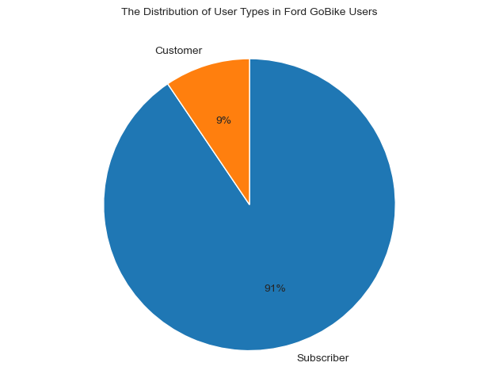

```python
sorted_counts = bike_df_copy['user_type'].value_counts()

plt.pie(sorted_counts, labels = sorted_counts.index, autopct='%1.0f%%', startangle=90, counterclock = False)

plt.title("The Distribution of User Types in Ford GoBike Users", fontsize=10, y=1.07)

plt.axis('equal') # Change to 'equal' to ensure the pie chart is a circle
plt.tight_layout() # add tight layout to ensure the title and labels are fully visible

plt.show()
```

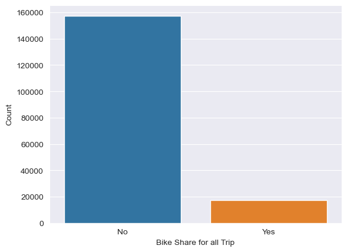

```python
sns.countplot(data = bike_df_copy, x='bike_share_for_all_trip')
plt.xlabel('Bike Share for all Trip');
plt.ylabel('Count');
```

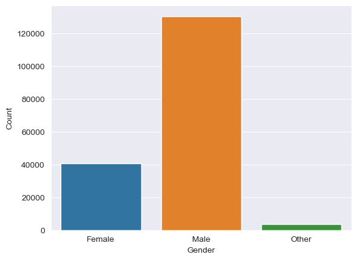

```python
sns.countplot(data = bike_df_copy, x='member_gender')
plt.xlabel('Gender');
plt.ylabel('Count');
```

### Observation

- The subscriber were more represented in the Ford Go Bike company with 91% as compared to customer with just 9%
- Majority of the users did not share trip
- The Male gender is more represented compared to other gender types

### Question

- Number of rides per weekday

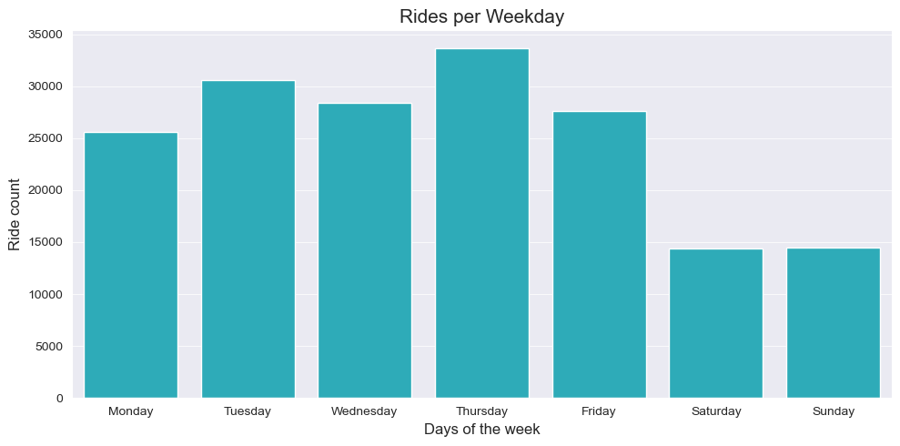

```python
week_order = ['Monday', 'Tuesday', 'Wednesday', 'Thursday', 'Friday', 'Saturday', 'Sunday']
base_color = sns.color_palette()[-1]

plt.figure(figsize=[10,5]) # set the figure size
sns.countplot(data = bike_df_copy, x = 'start_day_of_week', order = week_order, color = base_color)

# add a title and labels
plt.title('Rides per Weekday', fontsize = 15)
plt.xlabel('Days of the week', fontsize = 12)
plt.ylabel('Ride count', fontsize = 12)

# add tick marks and labels
plt.xticks(fontsize=10, rotation=0)
plt.yticks(fontsize=10)

# add grid
plt.grid(axis='y', alpha=0.75)

# tighten the plot layout
plt.tight_layout()

plt.show()
```

### Observation

- Thursday and Tuesday had the highest trip number
- More trips were taken on weekdays compared to weekends.

### Question

- What hour of the day is more trips taken?

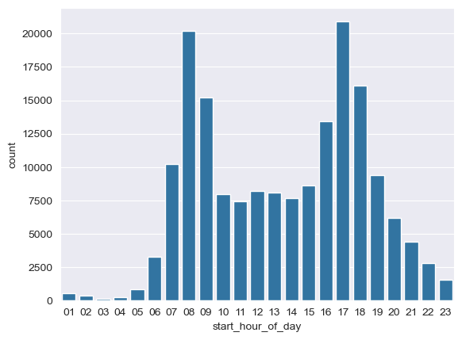

```python
hours = ['01', '02', '03','04', '05', '06','07', '08', '09', '10', '11', '12','13', '14', '15','16', '17', '18', '19','20', '21', '22','23']
color = sns.color_palette()[0]
sns.countplot(data = bike_df_copy, x = 'start_hour_of_day',
              color = color, order = hours)
```

### Question

How are the ages of the riders distributed?

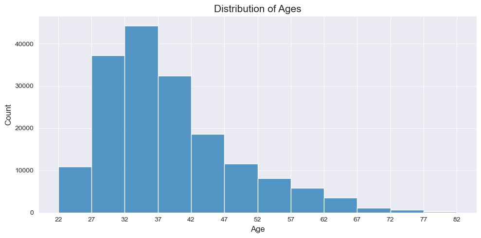

```python
plt.figure(figsize=[10,5]) # set the figure size

# plot a histogram of the ages
bin_edges = np.arange(bike_df_copy['age'].min(),bike_df_copy['age'].max()+5,5)
sns.histplot(data = bike_df_copy, x = 'age', color = sns.color_palette()[0], kde = False, bins = bin_edges);

# add a title and labels
plt.title('Distribution of Ages', fontsize = 15)
plt.xlabel('Age', fontsize = 12)
plt.ylabel('Count', fontsize = 12)

# add tick marks and labels
plt.xticks(bin_edges, fontsize=10)
plt.yticks(fontsize=10)

# add grid
plt.grid(axis='y', alpha=0.75)

# tighten the plot layout
plt.tight_layout()

plt.show()
```

### Observation

- Most of the riders are within the age bracket of 27 to 42

### Question

- Trip durations distribution

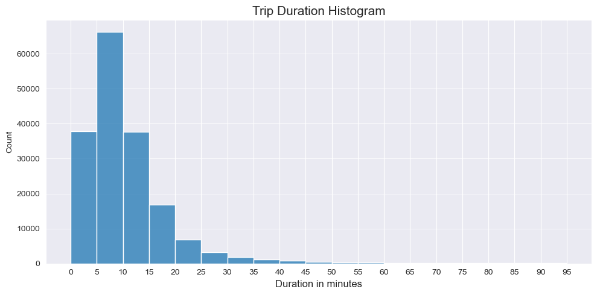

```python
bin_edges = np.arange(0, 100, 5)

plt.figure(figsize=[10,5]) # set the figure size

# plot a histogram of the trip durations
sns.histplot(data = bike_df_copy, x = 'duration_mins', color = sns.color_palette()[0], kde = False, bins = bin_edges)

# add a title and labels
plt.title("Trip Duration Histogram", fontsize=15)
plt.xlabel('Duration in minutes', fontsize=12)

# add tick marks and labels
plt.xticks(np.arange(0, 100, 5), fontsize=10)
plt.yticks(fontsize=10)

# add grid
plt.grid(axis='y', alpha=0.75)

# tighten the plot layout
plt.tight_layout()

plt.show()
```

### Observation

The distribution is right-skewed with most trips lasting around 5-15 minutes

```python
#Save the cleaned dataset
bike_df_copy.to_csv('fordgobike_tripdata_clean.csv', index=False)
```

## Bivariate Exploration

- Average trip duration on gender
- Average trip durartion on user type
- Durations of trip with respect to the days of the week
- Distribution of age of riders on days of the week
- Weekly usage between customers
- Weekly usage between gender
- User type usage for bike sharing

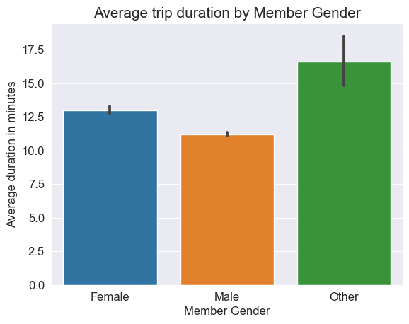

```python
# Plotting the bar plot using seaborn library
sns.barplot(data=bike_df_copy, x = 'member_gender', y= 'duration_mins')

# Adding x-axis label
plt.xlabel('Member Gender', fontsize=12)

# Adding y-axis label
plt.ylabel('Average duration in minutes', fontsize=12)

# Adding title to the plot
plt.title('Average trip duration by Member Gender', fontsize = 15)

# Increasing size of the title font
plt.rcParams["axes.titlesize"] = 20

# Increasing size of the axis labels font
plt.rcParams["axes.labelsize"] = 15

# Increasing size of the tick labels font
plt.tick_params(labelsize=12)

# Showing the plot
plt.show()
```

### Observation

The male riders spent slightly shorter time on trips when compared to the Female/Other gender group

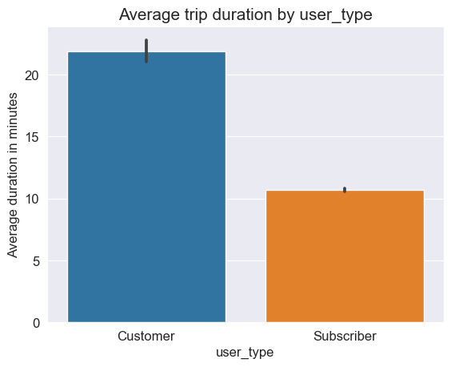

```python
# Plotting the bar plot using seaborn library
sns.barplot(data=bike_df_copy, x = 'user_type', y= 'duration_mins')

# Adding x-axis label
plt.xlabel('user_type', fontsize=12)

# Adding y-axis label
plt.ylabel('Average duration in minutes', fontsize=12)

# Adding title to the plot
plt.title('Average trip duration by user_type', fontsize = 15)

# Increasing size of the title font
plt.rcParams["axes.titlesize"] = 20

# Increasing size of the axis labels font
plt.rcParams["axes.labelsize"] = 15

# Increasing size of the tick labels font
plt.tick_params(labelsize=12)

# Showing the plot
plt.show()
```

### Observation

The Customers spend longer time on trip when compared to the subscribers

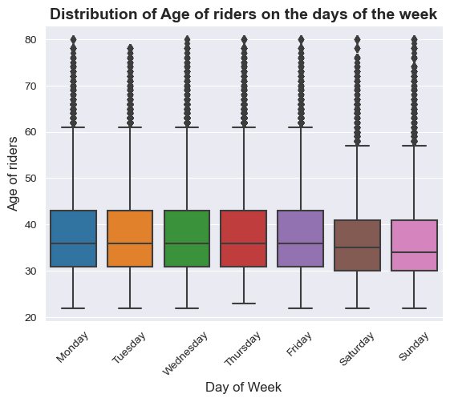

```python
sns.boxplot(x='start_day_of_week', y='age', data=bike_df_copy, order=week_order)

plt.xlabel('Day of Week', fontsize=12)
plt.ylabel('Age of riders', fontsize=12)
plt.title('Distribution of Age of riders on the days of the week', fontsize=14, fontweight='bold')

plt.xticks(rotation=45)

plt.show()
```

### Observation

The riders on the weekdays (Monday-Friday) are slightly older than the ones who operated on sundays

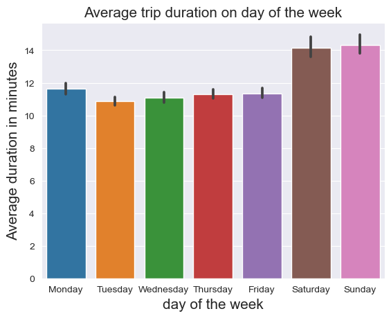

```python
sns.barplot(data=bike_df_copy, x = 'start_day_of_week', y= 'duration_mins', order = week_order)
plt.xlabel('day of the week')
plt.ylabel('Average duration in minutes')
plt.title('Average trip duration on day of the week', fontsize = 15)
plt.show()
```

### Observation

Rides taken on weekends are longer than those on weekdays(Monday-Friday)

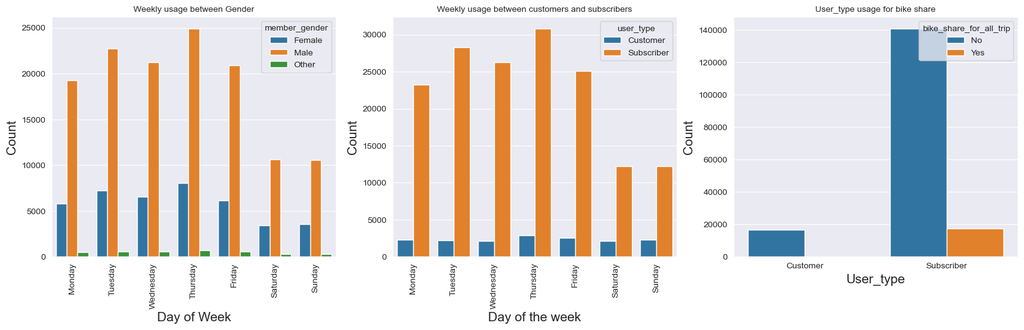

```python
fig, ax = plt.subplots(nrows=1, ncols=3, figsize=(20,5))
week_order = ['Monday', 'Tuesday', 'Wednesday', 'Thursday', 'Friday', 'Saturday', 'Sunday']

sns.countplot(data=bike_df_copy, x='start_day_of_week', hue='member_gender', ax=ax[0], order=week_order)
ax[0].set_xlabel('Day of Week');
ax[0].set_ylabel('Count');
ax[0].set_title("Weekly usage between Gender", fontsize=10)
ax[0].set_xticklabels(week_order,rotation=90)

sns.countplot(data=bike_df_copy, x='start_day_of_week', hue='user_type', ax=ax[1],order=week_order)
ax[1].set_xlabel('Day of the week');
ax[1].set_ylabel('Count');
ax[1].set_title("Weekly usage between customers and subscribers",fontsize=10)
ax[1].set_xticklabels(week_order,rotation=90)

sns.countplot(data=bike_df_copy, x='user_type', hue='bike_share_for_all_trip', ax=ax[2])
ax[2].set_xlabel('User_type');
ax[2].set_ylabel('Count');
ax[2].set_title("User_type usage for bike share",fontsize=10)

plt.show()
```

### Observation

- Male gender used the bike renting more from monday to sunday, followed by the female and other gender group in that order.
- There were much more subscribers than coustomers overall. The difference between subscribers' and constomers weekend usage reveals that subscribers use bikes mostly for getting to and from work during the week, while customers weekend usage shows that subscribers use bikes primarily for leisure, touring, and relaxing.
- The customers do not have a package that allows for bike sharing, even though the subscriber could share they had way more less bike sharing compared to the shared ones.

## Multivariate Exploration

- variation of average trip duration with member gender between user type
- variation of average trip duration in weekdays between user type

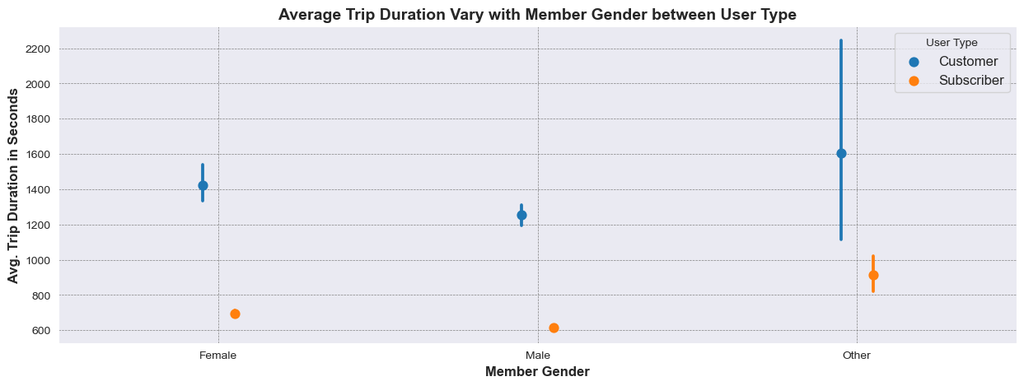

```python
fig, ax = plt.subplots(figsize=(15, 5))
sns.pointplot(data=bike_df_copy, x='member_gender', y='duration_sec', hue='user_type', dodge=0.1, linestyles="", ax=ax)

ax.set_xlabel('Member Gender', fontsize=12, fontweight='bold')
ax.set_ylabel('Avg. Trip Duration in Seconds', fontsize=12, fontweight='bold')
ax.set_title('Average Trip Duration Vary with Member Gender between User Type', fontsize=14, fontweight='bold')

ax.legend(title='User Type', fontsize=12)
ax.grid(color='gray', linestyle='--', linewidth=0.5)

plt.show()
```

### Observations

For both types of users the other gender group spent more time on trips, this is then followed by the female then male in that order

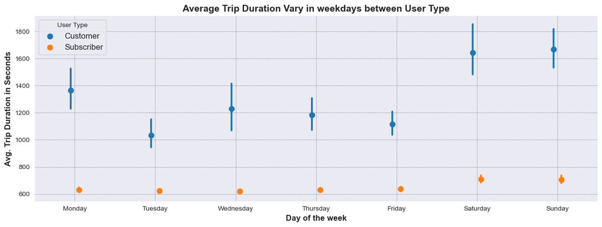

```python
fig, ax = plt.subplots(figsize=(15, 5))
sns.pointplot(data=bike_df_copy, x='start_day_of_week', y='duration_sec', hue='user_type', dodge=0.1, linestyles="", ax=ax,order = week_order)

ax.set_xlabel('Day of the week', fontsize=12, fontweight='bold')
ax.set_ylabel('Avg. Trip Duration in Seconds', fontsize=12, fontweight='bold')
ax.set_title('Average Trip Duration Vary in weekdays between User Type', fontsize=14, fontweight='bold')

ax.legend(title='User Type', fontsize=12)
ax.grid(color='gray', linestyle='--', linewidth=0.5)

plt.show()
```

### Observation

According to the graph above, subscribers travel more quickly than regular customers every day of the week. Trip time notably increases on Saturdays and Sundays for both user categories, particularly for customer. The average duration of subscriber usage was significantly more consistent than that of all customers from Monday through Friday.

## Conclusions

- The highest number of trips were taken in the on thursdays and Tuesday, weekends (Saturday and Sunday) had the lowest number of trips.
- A higher percentage of the users are subscribers accounting for about 91%, while the customer take up 9%.
- The male gender were more represented among the users in Ford Go-bike.
- The number of trips peak from 7am-9am during daytime and 4pm -7pm in the evening
- Customer spend longer time on trips compared to subscribers
- Male gender spend slightly shorter tine on trips compared to Female/Other gender
- No subscription package available for customers to share trips
- Customer travel longer duration regardless of the day of the week than the subscribers.
- For both types of users the other gender group spent more time on trips, this is then followed by the female then male in that order

```python
from subprocess import call
call(['python', '-m', 'nbconvert', 'Ford_Go_Bike_Data_Part 1_Exploration.ipynb'])
```

```
1
```